# temp-163440126545493665

**CLIMATE CHANGE EARTH SURFACE TEMPERATURE**

We are going to see the climate change around the world and the temperatuer difference on the earth through out the years. According to wikipedia Global warming, also referred to as climate change, is the observed century-scale rise in the average temperature of the Earth’s climate system and its related effects.

The word is climate change is one of the biggest existential threat that humanity is facing. Hoping to throw some exploratory light on the matter with the given data.

**EXPLORATORY DATA ANALYSIS**

*EDA*

**Importing all the necessary libraries**

```python
import numpy as np
import pandas as pd
import matplotlib.pyplot as plt
import seaborn as sns
import os
for dirname, _, filenames in os.walk('/kaggle/input'):
    for filename in filenames:
        print(os.path.join(dirname, filename))
```

```
/kaggle/input/climate-change-earth-surface-temperature-data/GlobalTemperatures.csv
/kaggle/input/climate-change-earth-surface-temperature-data/GlobalLandTemperaturesByState.csv
/kaggle/input/climate-change-earth-surface-temperature-data/GlobalLandTemperaturesByCountry.csv
/kaggle/input/climate-change-earth-surface-temperature-data/GlobalLandTemperaturesByCity.csv
/kaggle/input/climate-change-earth-surface-temperature-data/GlobalLandTemperaturesByMajorCity.csv
```

```python
Temp_1=pd.read_csv('../input/climate-change-earth-surface-temperature-data/GlobalTemperatures.csv')
```

```python
Temp_1.columns
```

```
Index(['dt', 'LandAverageTemperature', 'LandAverageTemperatureUncertainty',
       'LandMaxTemperature', 'LandMaxTemperatureUncertainty',
       'LandMinTemperature', 'LandMinTemperatureUncertainty',
       'LandAndOceanAverageTemperature',
       'LandAndOceanAverageTemperatureUncertainty'],
      dtype='object')
```

```python
Temp=Temp_1.copy()
```

```python
Temp.shape
```

```
(3192, 9)
```

OBSERVATION:

```python
Temp.columns
```

```
Index(['dt', 'LandAverageTemperature', 'LandAverageTemperatureUncertainty',
       'LandMaxTemperature', 'LandMaxTemperatureUncertainty',
       'LandMinTemperature', 'LandMinTemperatureUncertainty',
       'LandAndOceanAverageTemperature',
       'LandAndOceanAverageTemperatureUncertainty'],
      dtype='object')
```

OBSERVATION:

The 9 columns are 1)dt 2)LandAverageTemparature 3) LandAverageTemparateUncertainty 4) LandMaxTemperature 5) LandMaxTemperatureUncertainty 6) LandMinTemperature 7) LandMinTemperatureUncertainty 8) LandAndOceanAverageTemperature 9) LandAndOceanAverageTemperatureUncertainty

```python
Temp.head
```

```
<bound method NDFrame.head of               dt  LandAverageTemperature  LandAverageTemperatureUncertainty  \
0     1750-01-01                   3.034                              3.574
1     1750-02-01                   3.083                              3.702
2     1750-03-01                   5.626                              3.076
3     1750-04-01                   8.490                              2.451
4     1750-05-01                  11.573                              2.072
...          ...                     ...                                ...
3187  2015-08-01                  14.755                              0.072
3188  2015-09-01                  12.999                              0.079
3189  2015-10-01                  10.801                              0.102
3190  2015-11-01                   7.433                              0.119
3191  2015-12-01                   5.518                              0.100

      LandMaxTemperature  LandMaxTemperatureUncertainty  LandMinTemperature  \
0                    NaN                            NaN                 NaN
```

[output cut: 38 more lines]

OBSERVATION:

```python
missing=Temp.isnull().sum()
```

```python
missing
```

```
dt                                              0
LandAverageTemperature                         12
LandAverageTemperatureUncertainty              12
LandMaxTemperature                           1200
LandMaxTemperatureUncertainty                1200
LandMinTemperature                           1200
LandMinTemperatureUncertainty                1200
LandAndOceanAverageTemperature               1200
LandAndOceanAverageTemperatureUncertainty    1200
dtype: int64
```

OBSERVATION:

we can observe that maximum all the columns has null values only one column i.e dt has no null values

Remaining all the columns have null values. They need to be filled up with appropriate values later on

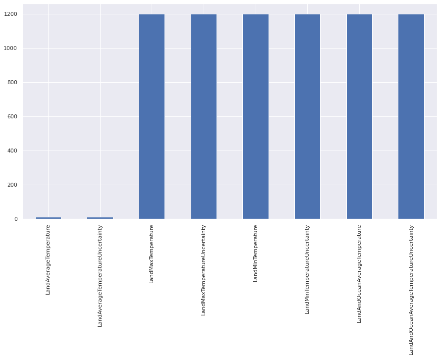

```python
missing=missing[missing>0]
missing.sort_values(inplace=True)
plt.figure(figsize=(15,8))
missing.plot.bar()
```

OBSERVATION:

In the above graph we can observe that LandAverageTemparature and LandAverageTemparatureUncertainty has very less null values i.e. in range of 10-20 whereas remaining all the columns has equal null values I.e in tha range of 1100-1200

```python
Temp.dtypes.value_counts()
```

```
float64    8
object     1
dtype: int64
```

OBSERVATION:

8 columns are Floating point numbers and 1 columns are object data type which is Text or mixed numeric and non-numeric values

```python
Temp['dt'].describe()
```

```
count           3192
unique          3192
top       1750-01-01
freq               1
Name: dt, dtype: object
```

OBSERVATION:

This returns Different stats like count of values, unique values, top and frequency of occurences in this case, top and name. Here the count of values are 3192 ,and it has 3192 unique values, and frequency of occurences are 1

**HISTOGRAM**

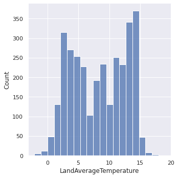

```python
sns.set(rc={'figure.figsize':(12,8)})
sns.displot(Temp['LandAverageTemperature'], kde=False, bins=20) ;
```

OBSERVATION:

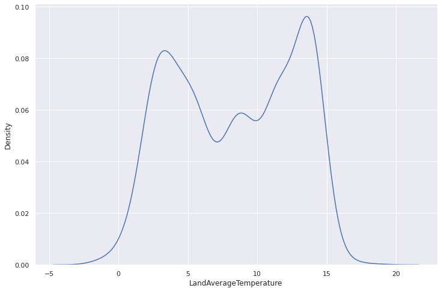

```python
sns.kdeplot(Temp['LandAverageTemperature'])
```

OBSERVATION:

```python
Temp['LandAverageTemperature'].describe()
```

```
count    3180.000000
mean        8.374731
std         4.381310
min        -2.080000
25%         4.312000
50%         8.610500
75%        12.548250
max        19.021000
Name: LandAverageTemperature, dtype: float64
```

OBSERVATION:

**SCATTERPLOT**

Scatter plots use a collection of points placed using Cartesian coordinates to display values from two variables. By displaying a variable in each axis, we can detect if a relationship or correlation between the two variables exists. Scatter Plots are also great for observing the spread of the data as they retain the exact data values and sample size.

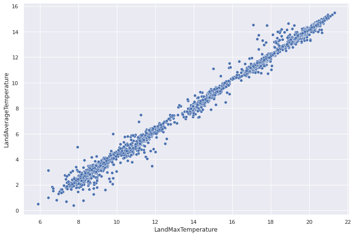

```python
sns.scatterplot(x='LandMaxTemperature', y='LandAverageTemperature', data=Temp)
```

OBSERVATION:

This scatter plot shows LandMaxTemperature on x-axis and LandAverageTemparature on Y-axis.

**CORRELATION**

correlation can be calculated only on numerical columns we can't caluculate correlation on non-numeric

```python
numeric_features = Temp.select_dtypes(include = [np.number])
numeric_features.columns
```

```
Index(['LandAverageTemperature', 'LandAverageTemperatureUncertainty',
       'LandMaxTemperature', 'LandMaxTemperatureUncertainty',
       'LandMinTemperature', 'LandMinTemperatureUncertainty',
       'LandAndOceanAverageTemperature',
       'LandAndOceanAverageTemperatureUncertainty'],
      dtype='object')
```

OBSERVATION:

Here numeric columns are stored in variable called number if features and columns are extracted. We can see that nearly 8 columns out of 9 have numerical values

```python
numeric_features1 = Temp.select_dtypes(exclude = ['O'])
numeric_features1.columns
```

```
Index(['LandAverageTemperature', 'LandAverageTemperatureUncertainty',
       'LandMaxTemperature', 'LandMaxTemperatureUncertainty',
       'LandMinTemperature', 'LandMinTemperatureUncertainty',
       'LandAndOceanAverageTemperature',
       'LandAndOceanAverageTemperatureUncertainty'],
      dtype='object')
```

OBSERVATION:

Here numeric columns are extracted excluding strings

```python
numeric_features.shape, numeric_features1.shape
```

```
((3192, 8), (3192, 8))
```

OBSERVATION:

it gives number of numeric columns are there. We can get concluded that nearly 8 colums have numeric values

```python
categorical_features = Temp.select_dtypes(include = [np.object])
categorical_features.columns
```

```
Index(['dt'], dtype='object')
```

OBSERVATION:

It gives all the string columns. We have nearly 1 string columns

The one string column is date column

```python
categorical_features.shape
```

```
(3192, 1)
```

```python
correlation = numeric_features.corr()
print(correlation['LandAverageTemperature'].sort_values(ascending = False), '\n')
```

```
LandAverageTemperature                       1.000000
LandMaxTemperature                           0.995807
LandMinTemperature                           0.995611
LandAndOceanAverageTemperature               0.988066
LandMaxTemperatureUncertainty               -0.108462
LandAndOceanAverageTemperatureUncertainty   -0.131412
LandMinTemperatureUncertainty               -0.167451
LandAverageTemperatureUncertainty           -0.204191
Name: LandAverageTemperature, dtype: float64
```

OBSERVATION:

To find the correlation between numerical features we are using corr method

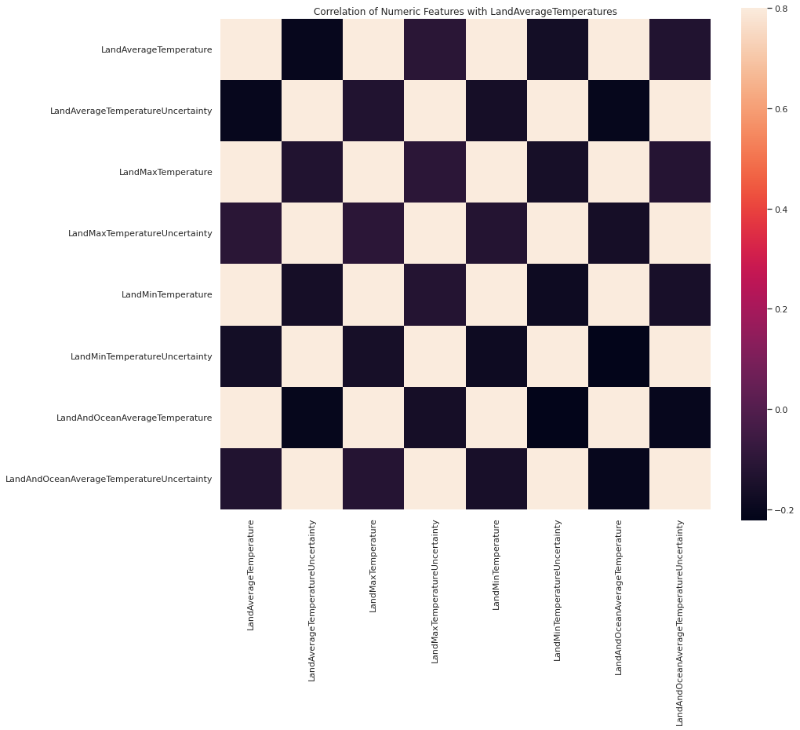

```python
f, ax = plt.subplots(figsize = (14, 12))
plt.title('Correlation of Numeric Features with LandAverageTemperatures')
sns.heatmap(correlation, square=True, vmax=0.8)
```

OBSERVATION:

```python
k=5
cols = correlation.nlargest(k, 'LandAverageTemperature')['LandAverageTemperature'].index
print(cols)
```

```
Index(['LandAverageTemperature', 'LandMaxTemperature', 'LandMinTemperature',
       'LandAndOceanAverageTemperature', 'LandMaxTemperatureUncertainty'],
      dtype='object')
```

OBSERVATION:

it shows the 5 numerical columns

[figure not shown]

```python
cm = np.corrcoef(Temp[cols].values.T)
f, ax = plt.subplots(figsize = (14, 12))
sns.heatmap(cm, vmax=0.8, linewidths=0.01, square=True, annot=True, cmap='viridis', linecolor='white', xticklabels=cols.values, yticklabels=cols.values)
```

OBSERVATION:

Here correlation matrix for top 5 columns was plotted

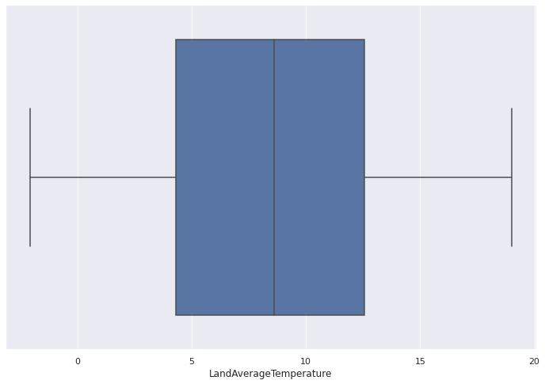

```python
sns.boxplot(Temp['LandAverageTemperature'])
```

[figure not shown]

```python
f, ax = plt.subplots(figsize = (16,10))
fig = sns.boxplot(x='LandMaxTemperature', y='LandAverageTemperature', data=Temp)
fig.axis(ymin=0, ymax=800000)
xt = plt.xticks(rotation = 45)
```

OBSERVATION:

Here boxplot is plotted between LandMaxTemperature on x axis and LandAverageTemparature on y-axis

```python
Temp['LandAverageTemperature'].unique()
```

```
array([ 3.034,  3.083,  5.626, ..., 10.801,  7.433,  5.518])
```

We can observe the array of all the LandAverageTemparature that has unique values

```python
Temp['LandAverageTemperature'].nunique()
```

```
2839
```

OBSERVATION:

Here we can observe that nearly 2839 LandAverageTemparature had unique values

```python
Temp['LandAverageTemperature'].value_counts()
```

```
13.765    4
13.293    4
3.099     3
2.039     3
11.097    3
         ..
8.526     1
5.160     1
2.613     1
2.156     1
5.518     1
Name: LandAverageTemperature, Length: 2839, dtype: int64
```

OBSERVATION:

It gives the value counts of Land average temperature in Temp

[output not shown]

[figure not shown]

```python
f, ax = plt.subplots(figsize = (12,8))
fig = sns.boxplot(x='LandMaxTemperatureUncertainty', y='LandMaxTemperatureUncertainty', data=Temp
)
fig.axis(ymin=0, ymax=800000)
```

```python
Temp['LandMaxTemperature'].value_counts()
```

```
20.037    3
8.555     3
19.987    3
17.713    3
10.781    3
         ..
19.539    1
20.058    1
19.287    1
17.146    1
12.892    1
Name: LandMaxTemperature, Length: 1814, dtype: int64
```

**DATA CLEANING**